# Bike_share_Project

Nick Osaghae

2023-07-04

# Cyclistic Inc. Marketing Campaign

## Bike_sharing service membership

**Title: Bike sharing service memberships**

**Introduction:**

The Bike Share service is a significant innovation in a world that is increasingly conscious of carbon emissions. Cyclistic Inc, a Bike-share company based in Chicago, USA, has successfully launched a bike-share service comprising a fleet of 5,824 bicycles locked in 692 stations. These bicycles are equipped with geo-tracking technology and can be unlocked at one station and used until they are returned to another station at any time.

There are basically two customer types in Cyclystic, the annual subscribers which are called **members** and the single ride or full-day pass users considered **casual** riders.

The stakeholders at Cyclistic are currently engaged in a marketing campaign and firmly believe that the company’s future success hinges on maximizing the number of annual memberships. For this project, I made the decision to utilize the R programming language due to the substantial size of the dataset. In addition, I employed Tableau for enhanced visualization capabilities and Excel to handle smaller excerpts of dataframes.

**Buissiness Task:**

As data analysts within the marketing team, our objective is to examine the distinct usage patterns of casual riders and annual members of Cyclistic bikes. Through these insights, we aim to develop a new marketing strategy utilizing digital media. Our focus is on converting casual riders, who are already acquainted with the Cyclistic bike-share, into annual members, rather than targeting entirely new customers.

### This project follows the Ask,Prepare,Process,Analyze,Share, and Act phases of data analytics

#### Ask:

- In what ways do subscription types, members, and casual riders utilize bikes differently?
- What factors could motivate casual riders to purchase a membership?
- How can Cyclistic Inc. leverage digital media to persuade casual riders to transition into members?

Deliverable: A set of data-backed recommendations on how the marketing team can utilize digital media to influence casual riders to transition to a membership.

#### Prepare:

The Data set is **reliable**, **original**, **current**, **cited** and **Comprehensive**, therefore it meet’s the ROCCC test and it is suitable for data analysis. The raw dataset is located here [link](https://divvy-tripdata.s3.amazonaws.com/index.html) and made available under the divvy bike licence agreement [link](https://ride.divvybikes.com/data-license-agreement).

– Tasks: Download Bike-share data of the past 12 months from Divvy tripdata, upload each month into R and combine into a single dataset.

**installing and loading Packages**

```r
library(tidyverse)
```

**Importing the data from source folder**

```r
getwd()
```

```r
may22 <- read.csv("C:\\Users\\danie\\OneDrive\\Desktop\\Bike_Share\\202205-divvy-tripdata.csv")
june22 <- read.csv("C:\\Users\\danie\\OneDrive\\Desktop\\Bike_Share\\202206-divvy-tripdata.csv")
july22 <- read.csv("C:\\Users\\danie\\OneDrive\\Desktop\\Bike_Share\\202207-divvy-tripdata.csv")
aug22 <- read.csv("C:\\Users\\danie\\OneDrive\\Desktop\\Bike_Share\\202208-divvy-tripdata.csv")
sept22 <- read.csv("C:\\Users\\danie\\OneDrive\\Desktop\\Bike_Share\\202209-divvy-publictripdata.csv")
oct22 <- read.csv("C:\\Users\\danie\\OneDrive\\Desktop\\Bike_Share\\202210-divvy-tripdata.csv")
nov22 <- read.csv("C:\\Users\\danie\\OneDrive\\Desktop\\Bike_Share\\202211-divvy-tripdata.csv")
dec22 <- read.csv("C:\\Users\\danie\\OneDrive\\Desktop\\Bike_Share\\202212-divvy-tripdata.csv")
jan23 <- read.csv("C:\\Users\\danie\\OneDrive\\Desktop\\Bike_Share\\202301-divvy-tripdata.csv")
feb23 <- read.csv("C:\\Users\\danie\\OneDrive\\Desktop\\Bike_Share\\202302-divvy-tripdata.csv")
march <- read.csv("C:\\Users\\danie\\OneDrive\\Desktop\\Bike_Share\\202303-divvy-tripdata.csv")
april23 <- read.csv("C:\\Users\\danie\\OneDrive\\Desktop\\Bike_Share\\202304-divvy-tripdata.csv")
```

–Examine the data,if datatypes and data structures are compatible

```r
str(june22)
str(july22)
str(aug22)
str(sept22)
```

```r
june22$started_at <-strptime(as.character(june22$started_at), "%d/%m/%Y %H:%M")
june22$started_at <- format(june22$started_at,"%Y-%m-%d %H:%M:%S")

june22$ended_at <- strptime(as.character(june22$ended_at), "%d/%m/%Y %H:%M")
june22$ended_at <- format(june22$ended_at,"%Y-%m-%d %H:%M:%S")
```

– Combine the 12 months csv data

```r
year <- bind_rows(may22,june22,july22,aug22,sept22,oct22,nov22,dec22,jan23,feb23,march,april23)
```

#### Process:

**cleaning and modifying the data**

```r
str(year)
head(year)
glimpse(year)
nrow(year)
ncol(year)
```

```r
colnames(year)
```

```
##  [1] "ride_id"            "rideable_type"      "started_at"
##  [4] "ended_at"           "start_station_name" "start_station_id"
##  [7] "end_station_name"   "end_station_id"     "start_lat"
## [10] "start_lng"          "end_lat"            "end_lng"
## [13] "member_casual"
```

**The raw data has 5859061 rows and 13 columns of Ride id, Start and end dates,Start and end station names as well as latitudes and longitudes including subscriber type either member or casual and rideable bike type of either docked, electric or classic bikes.**

–Removing NAs in the data

```r
sum(is.na(year))
year <- na.omit(year)
dim(year)
```

– Find trip duration

```r
year01 <- year
year01$started_at <- as_datetime(year01$started_at)
year01$ended_at <- as_datetime(year01$ended_at)

year01$ride_len <- round(difftime(year01$ended_at,year01$started_at, units = "min",),digits = 2)
year01 <- year01 %>%
  arrange(ride_len)
```

– Fill out empty start station and end station names if possible through look up of latitudes and longitudes of rows with start and end station names.

```r
yearcl <- yearcl %>%
  filter(end_lat != 0)

yearcl <- yearcl %>%
  group_by(end_lat, end_lng) %>%
  mutate(end_station_name = ifelse(end_station_name == "", first(end_station_name), end_station_name)) %>%
  ungroup()

yearcl <- yearcl %>%
  group_by(start_lat, start_lng) %>%
  mutate(start_station_name = ifelse(start_station_name == "", first(start_station_name), start_station_name)) %>%
  ungroup()

dim(yearcl)
```

– Select all columns without the latitudes, longitudes and station ids and add new columns like the weekdays, year, month and day.

```r
yearcl_1 <- yearcl %>%
  select(ride_id,rideable_type,started_at,ended_at,start_station_name,end_station_name,member_casual,ride_len)
```

```r
yearcl$month <- format(as.Date(yearcl$started_at),"%m")
yearcl$day <- format(as.Date(yearcl$started_at),"%d")
yearcl$year <- format(as.Date(yearcl$started_at),"%Y")
yearcl$time <- format(yearcl$started_at, format = "%H")
```

– Created the weekday columns and convert it to class: ordered factor in order to know the most frequented days

```r
yearcl$weekdays <- weekdays(yearcl$started_at)
yearcl$weekdays <- factor(yearcl$weekdays, levels = c("Monday", "Tuesday","Wednesday","Thursday","Friday","Saturday","Sunday"))
class(yearcl$weekdays)
```

#### Analyze:

– I conducted a descriptive analysis to gain insights into the data, focusing on understanding the similarities and differences in how members and casual riders utilize the bike service. Additionally, I explored trends in subscriber type behavior, such as the average duration of rides, preferred bike choices, the busiest weekday, and the busiest start and end stations. Furthermore, I examined changes in ride numbers and counts over the monthly series to identify any notable patterns or fluctuations.

**Summary statistics:**

```
## Average duration of ride is:
## 16
## mins
## Maximum duration of ride is:
## 25
## hours
## Minimum duration of ride is:
## 0.02
## mins
```

#### Analyze and Visualize (Share)

– No of rides and duration of members and casual riders

– Visualize the percentage of member and casual subscribers

```r
yearcl %>%
  group_by(member_casual) %>%
  summarise(n=n()) %>%
  mutate(percent = n*100/sum(n))
```

```
## # A tibble: 2 × 3
##   member_casual       n percent
##   <chr>           <int>   <dbl>
## 1 casual        1986783    38.7
## 2 member        3153483    61.3
```

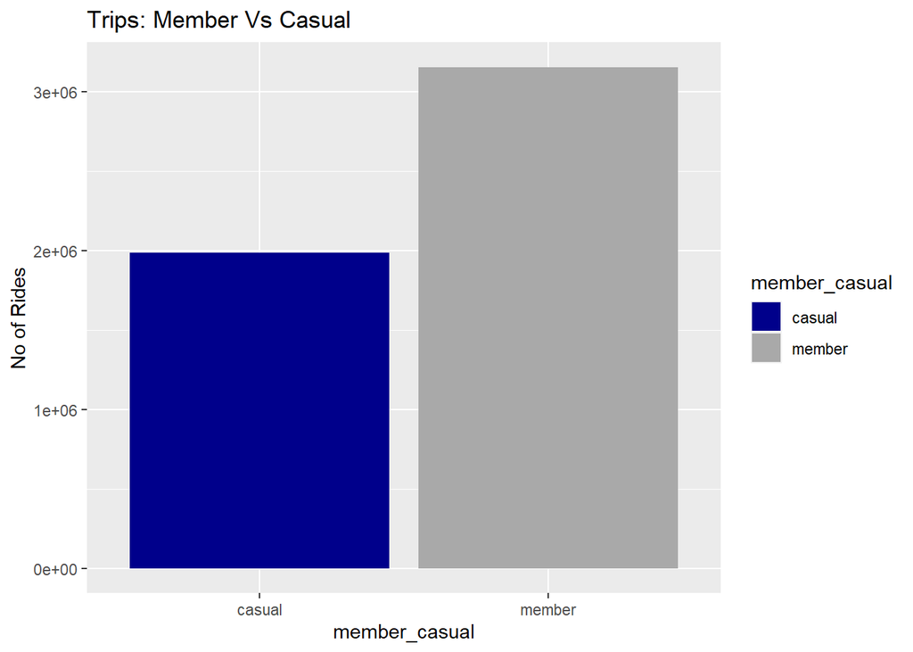

```r
ggplot(data = yearcl,mapping = aes(x = member_casual,fill = member_casual)) + geom_bar() +
  scale_fill_manual(values = c("darkblue", "darkgrey")) +
  labs(title =  "Trips: Member Vs Casual", y = "No of Rides")
```

**It is evident from the analysis that there is a higher number of trips made by members compared to casual riders. Cyclistic Inc. currently serves a larger customer base of members, but it is important to note that the number of casual riders is still significant.**

– Observe the duration of rides: Member Vs Casual–

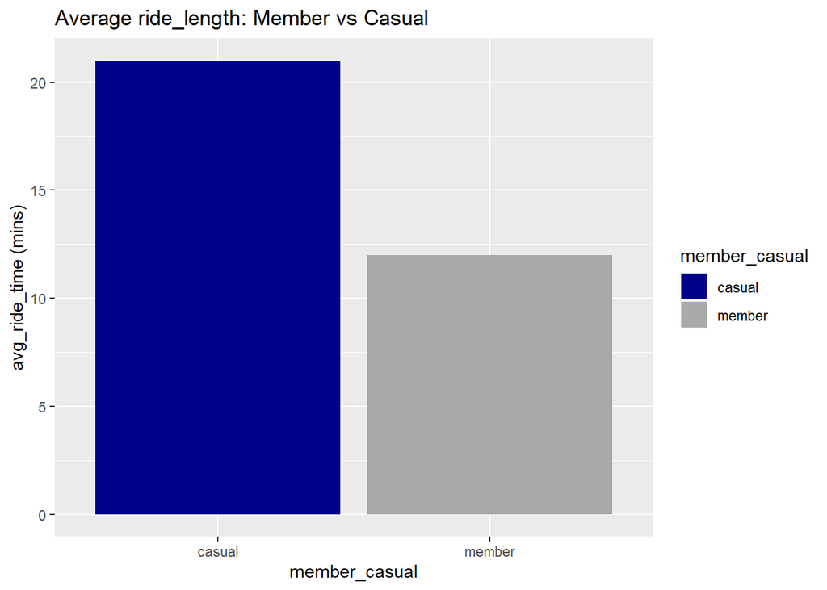

**Based on the data analysis, it is apparent that casual riders tend to take longer rides compared to users with membership cards, despite annual members being more frequent users. This observation leads us to infer that casual users might consider transitioning to membership if they are enticed by potential cost savings on longer trips that come with switching to a membership. By highlighting the financial benefits and emphasizing how membership can lead to significant savings on extended rides, Cyclistic Inc. could potentially encourage casual riders to convert into members.**

**Preferred Bike type by users: Which bikes do users prefer?**

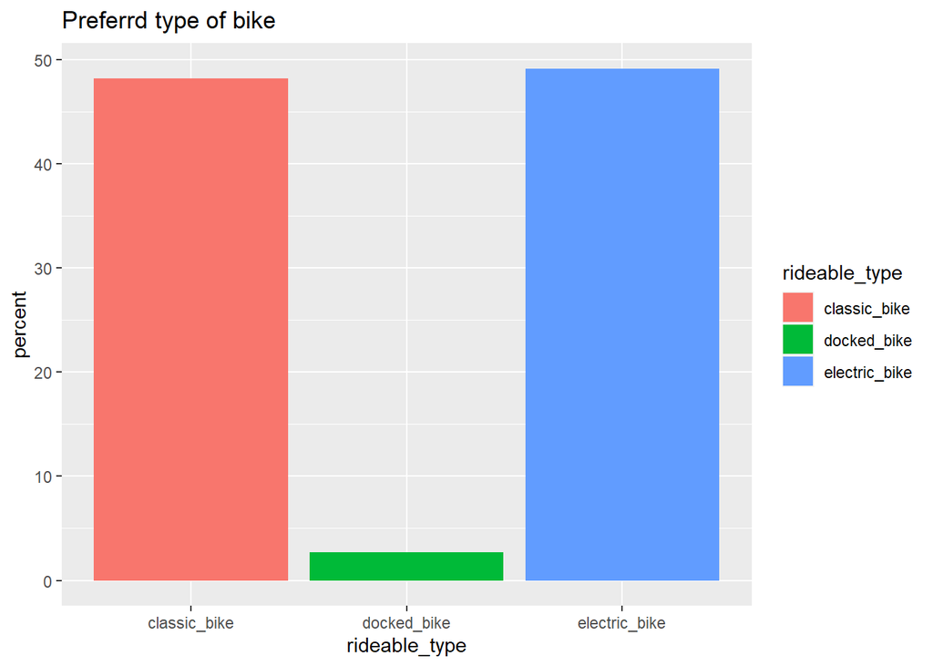

**Electric and classic bikes are the most preferred type of bikes, while docked bike seems to be the least preferred by users.**

– Preferred Bike type by members and casual riders

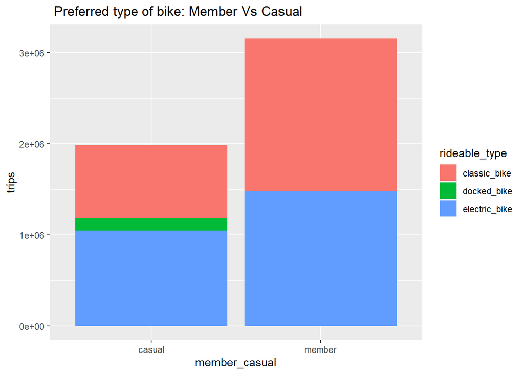

**The visualization indicated that only a small fraction of casual riders uses docked bike, the preference for classic bikes and electric bike is confirmed in both casual and member users.**

**Weekdays**

– What trends can be observed across weekdays, are some particular days in a week more frequented than others.

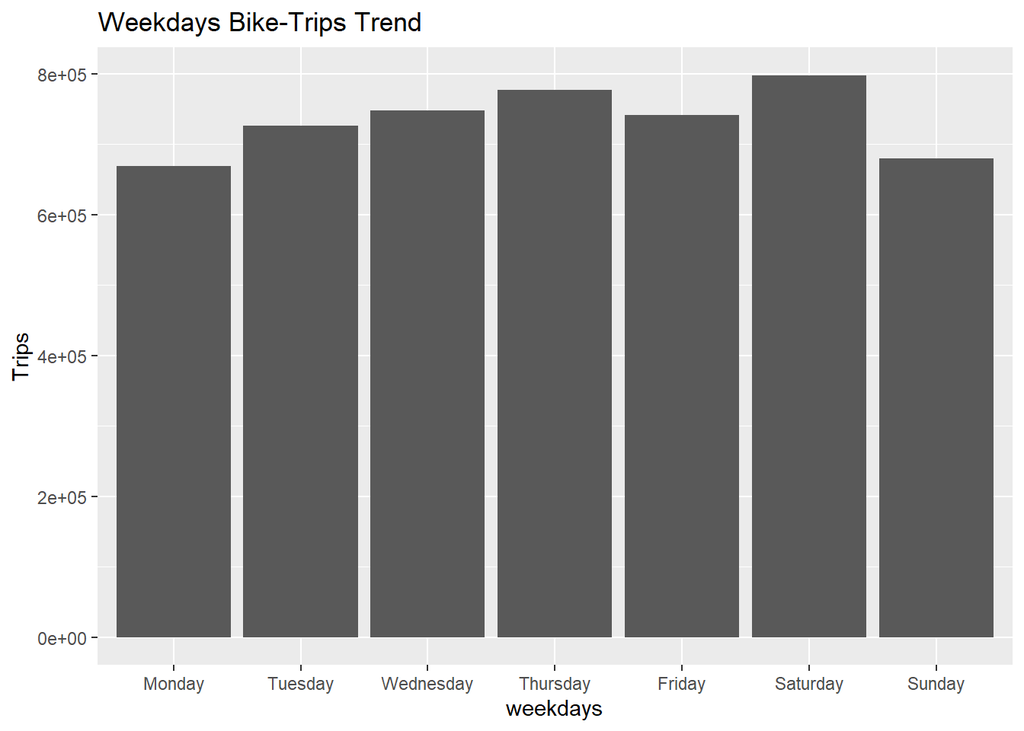

**While there doesn’t appear to be a significant difference between weekdays and weekends in terms of ride patterns, further analysis is needed to determine if there are divergent trends when rides are examined by subscriber type (member vs. casual). This evaluation will provide a clearer understanding of any variations in ride behavior between the two groups throughout the week.**

– What are the differences between member and casual usage during the week?

– Usage by week day: Member Vs Casual

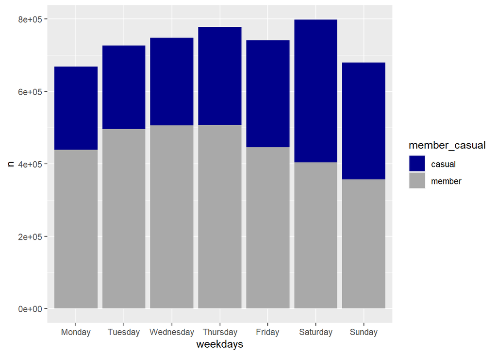

**We can clearly observe that casual riders uses the bike more during the weekends and members are more active during the week.**

–We can again observe this trend from this plot.

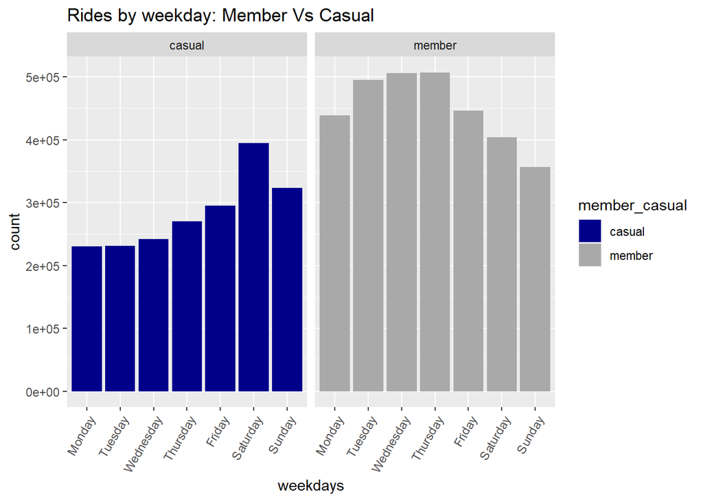

**Based on the analysis, it is evident that weekends are the peak activity days for casual riders, while members tend to take rides predominantly on weekdays.**

Monthly Ride By Type – We should observe monthly ride trends and how they differ between members and casual users

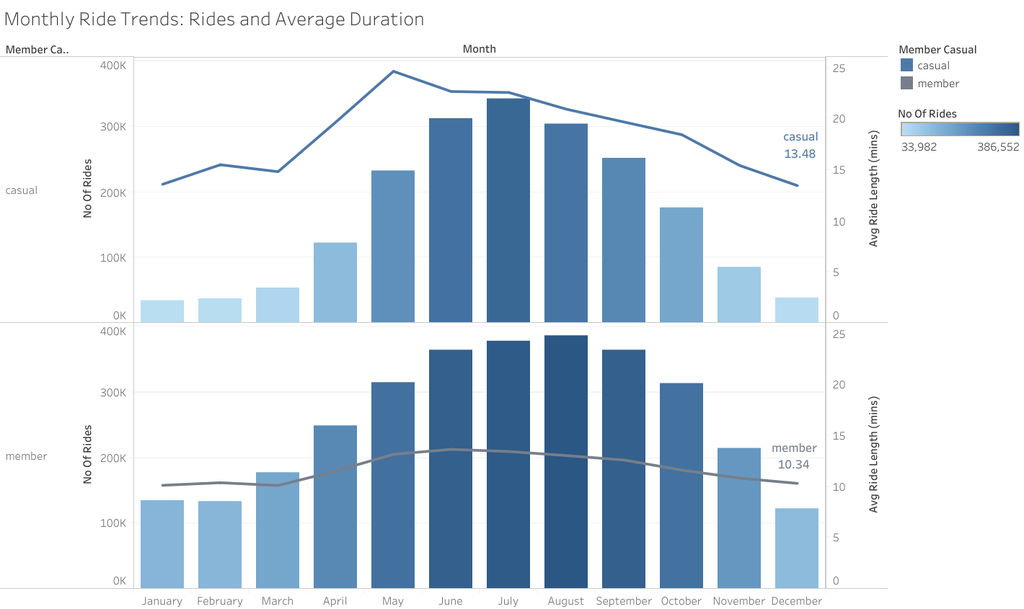

**The plotted data reveals a noticeable trend where trips experience a substantial increase starting from March, coinciding with the onset of spring, and gradually decrease by October. The months of May through September stand out as having the highest ride numbers for both casual and member subscribers, indicating a significant surge in activity during the summer season.**

– Observed in detail the difference in average ride length between members and casual users

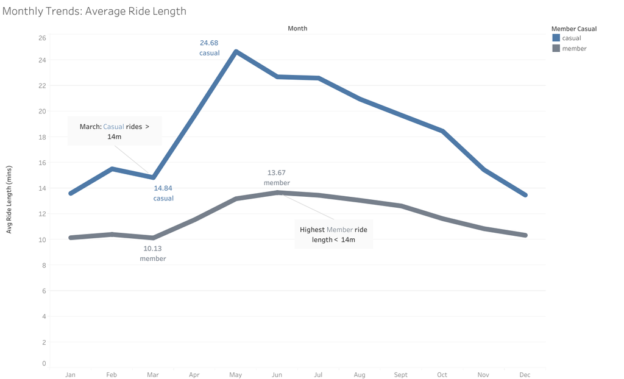

**The analysis reveals a notable disparity in average ride lengths between casual riders and members. Casual rides consistently exhibit considerably higher durations compared to members. This finding presents an opportunity to explore when attempting to convert casual riders into members. Notably, even at the start of the peak period in March, casual rides already exceed 14 minutes on average, a duration that members never reach throughout the entire series. Highlighting the potential cost savings on these longer rides by switching to membership could be a persuasive factor in encouraging casual riders to transition to become members.**

```r
Hourly <- yearcl %>%
  drop_na() %>%
  group_by(time, member_casual) %>%
  summarise(n = n(),
            avg_ride_length = mean(ride_len))
```

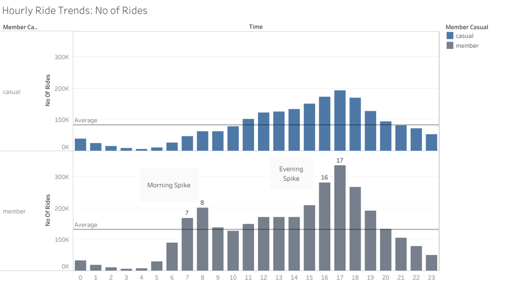

**We observed two peak periods, morning and evening, indicating that annual members are most likely students of workers**

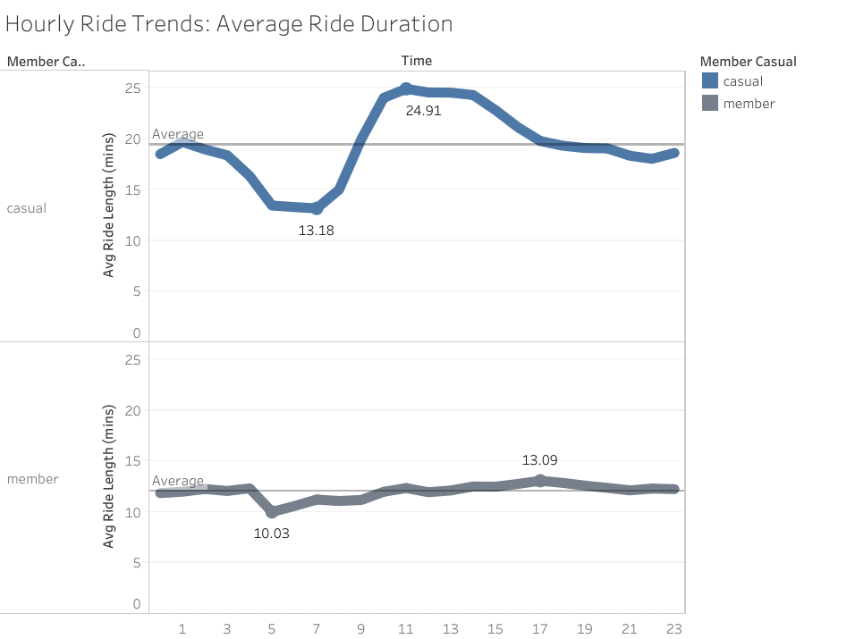

```r
start_stations_ca <- yearcl %>%
  drop_na() %>%
  filter(member_casual == "member") %>%
  filter(!start_station_name == "") %>%
  group_by(start_station_name) %>%
  summarise(n = n()) %>%
  arrange(desc(n)) %>%
  head(10)

start_stations_me <- yearcl %>%
  drop_na() %>%
  filter(member_casual == "casual") %>%
  filter(!start_station_name == "") %>%
  group_by(start_station_name) %>%
  summarise(n = n()) %>%
  arrange(desc(n)) %>%
  head(10)

end_stations <- yearcl %>%
  drop_na() %>%
  filter(!end_station_name == "") %>%
  group_by(end_station_name,member_casual) %>%
  summarise(n = n()) %>%
  arrange(desc=(n)) %>%
  head(12)
```

[figure not shown]

**We observed the most frequented starting stations users around these areas can be targeted for digital marketing campaign.**

#### Share and Act

**Observations**

- While there are more member trips than casual trips, casual riders tend to take longer trips.
- Analysis of weekday trends reveals that members primarily use bike trips during weekdays, likely for work or school purposes. In contrast, weekends show a higher proportion of casual riders, suggesting their rides are more recreational.
- Hourly trends further support the hypothesis that member riders are likely students or workers, with sharp increases in the morning (commuting to work or school) and evenings (returning).
- Monthly trends strongly indicate that bike usage increases during the warmer months, specifically from March to September. Additionally, while member trips have a moderate average ride duration, casual rides experience a sharp increase in duration from March onwards, with considerably higher durations than members.
- We have identified the most popular start stations based on the analysis.

**Recommendations**

Recommendations to encourage casual users to switch to annual memberships:

1. Enhance Membership Attractiveness:

   *Offer competitive prices for annual memberships, emphasizing the cost savings compared to casual rides, especially for longer trips.

   *Adjust pricing structure for casual rides to be more duration-dependent, incentivizing frequent users to opt for memberships.
2. Target Specific Segments in Digital Campaign:

   *Focus the digital campaign message on workers and students, highlighting the convenience and financial benefits of membership for their daily commuting needs.

   *Emphasize significant cost savings on longer trips through membership, appealing to casual riders who frequently take extended rides.
3. Time the Digital Campaign Strategically:

   *Launch the digital campaign around March, just as bike trips are expected to increase during the spring and summer seasons.